# Лабораторная работа №2

Структуры данных

Александр Эдуардович Аскеров

Российский университет дружбы народов

2025-09-27

# Информация

## Докладчик

- Аскеров Александр Эдуардович
- Кафедра теории вероятностей и кибербезопасности
- Российский университет дружбы народов им. П. Лумумбы

# Вводная часть

## Цель работы

Основная цель работы – изучить несколько структур данных, реализованных в Julia, научиться применять их и операции над ними для решения задач.

## Задание

1. Используя Jupyter Lab, повторите примеры из раздела 2.2.
2. Выполните задания для самостоятельной работы (раздел 2.4).

# Кортежи

Выполним примеры из раздела кортежи.

Кортеж (Tuple) – структура данных (контейнер) в виде неизменяемой индексируемой последовательности элементов какого-либо типа (элементы индексируются с единицы).

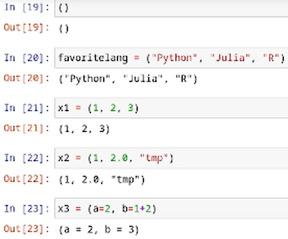

Рисунок 1: Кортежи 1

# Кортежи

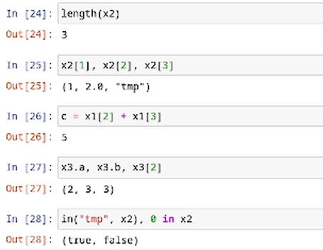

Рисунок 2: Кортежи 2

# Словари

Выполним примеры из раздела словари.

Словарь – неупорядоченный набор связанных между собой по ключу данных.

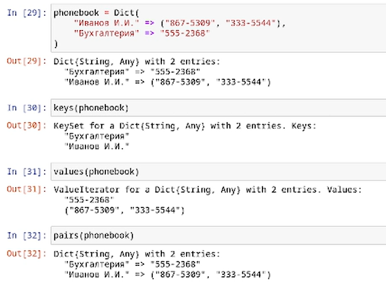

Рисунок 3: Словари 1

# Словари

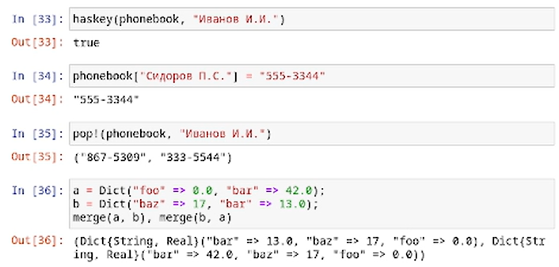

Рисунок 4: Словари 2

# Множества

Выполним примеры из раздела множества.

Множество, как структура данных в Julia, соответствует множеству, как математическому объекту, то есть является неупорядоченной совокупностью элементов какого-либо типа. Возможные операции над множествами: объединение, пересечение, разность; принадлежность элемента множеству.

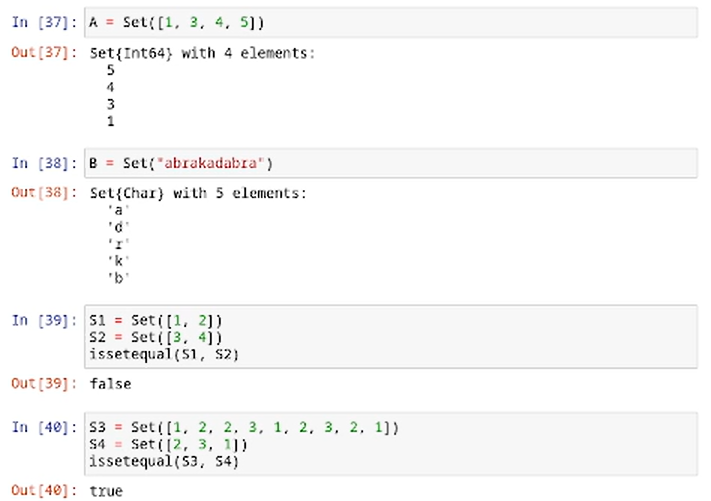

Рисунок 5: Множества 1

# Множества

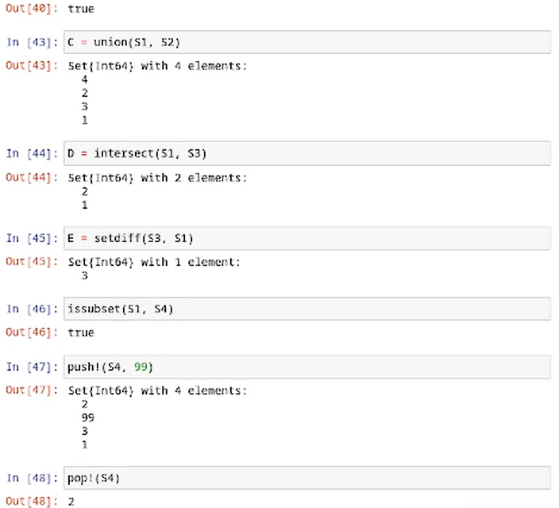

Рисунок 6: Множества 2

# Массивы

Выполним примеры из раздела массивы.

Массив – коллекция упорядоченных элементов, размещённая в многомерной сетке. Векторы и матрицы являются частными случаями массивов.

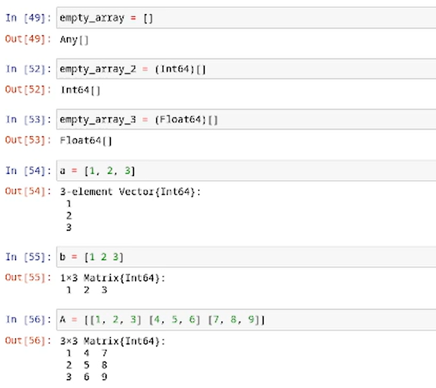

Рисунок 7: Массивы 1

# Массивы

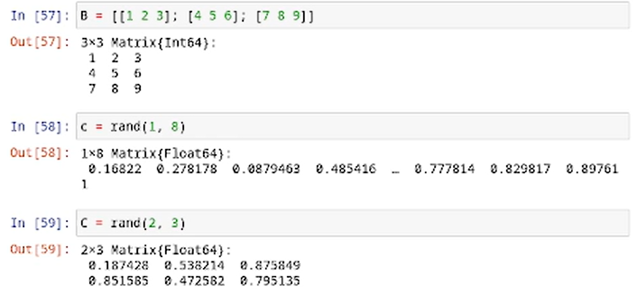

Рисунок 8: Массивы 2

# Массивы

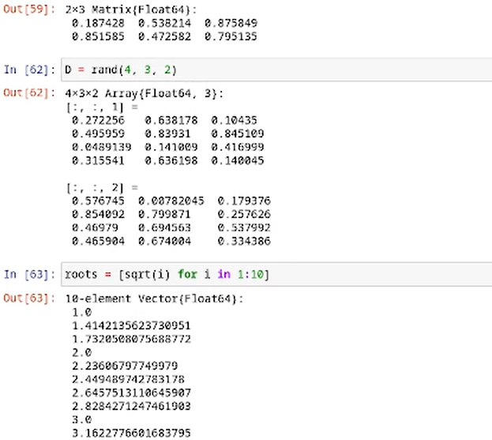

Рисунок 9: Массивы 3

# Массивы

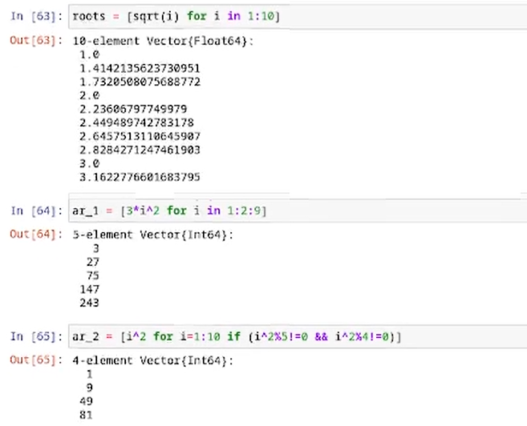

Рисунок 10: Массивы 4

# Массивы

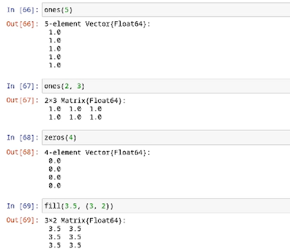

Рисунок 11: Массивы 5

# Массивы

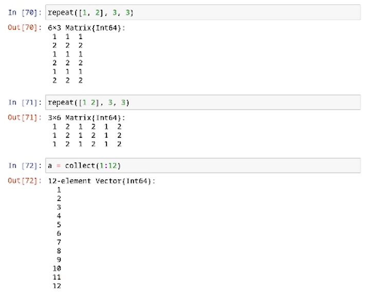

Рисунок 12: Массивы 6

# Массивы

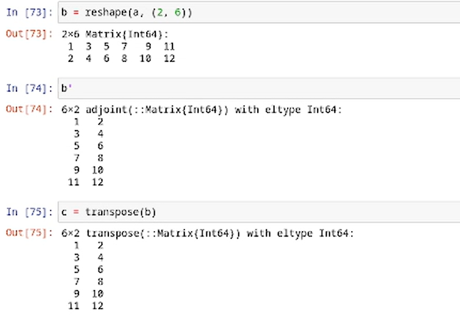

Рисунок 13: Массивы 7

# Массивы

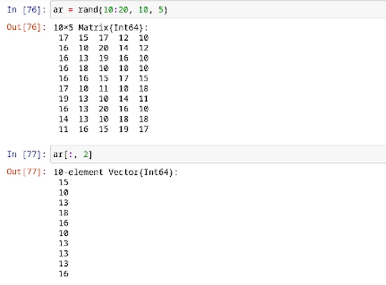

Рисунок 14: Массивы 8

# Массивы

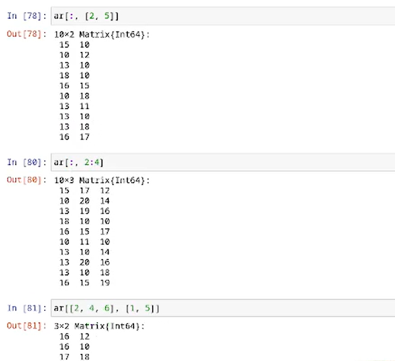

Рисунок 15: Массивы 9

# Массивы

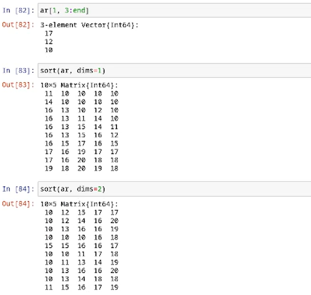

Рисунок 16: Массивы 10

# Массивы

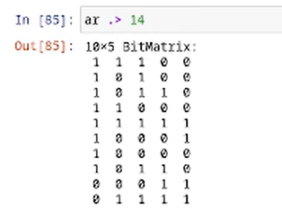

Рисунок 17: Массивы 11

# Массивы

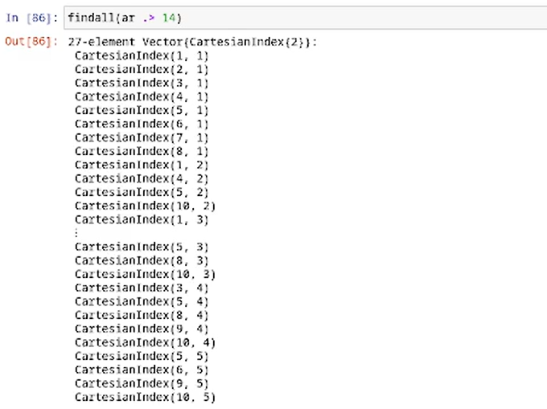

Рисунок 18: Массивы 12

# Задания для самостоятельной работы

*Задание 1.* Работа со множествами.

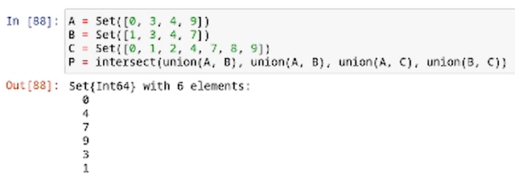

Рисунок 19: Работа со множествами

# Задания для самостоятельной работы

*Задание 2.* Операции над множествами элементов разных типов.

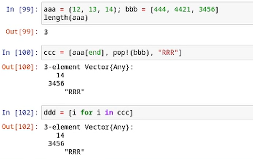

Рисунок 20: Операции над множествами элементов разных типов

# Задания для самостоятельной работы

*Задание 3.* Создание разными способами массивов и векторов.

Задание 3.1.

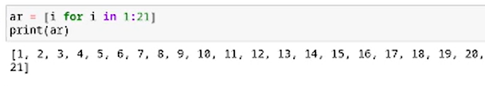

Рисунок 21: Задание 3.1

Задание 3.2.

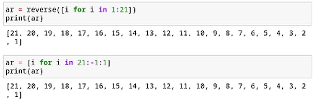

Рисунок 22: Задание 3.2

# Задания для самостоятельной работы

Задание 3.3.

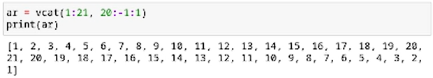

Рисунок 23: Задание 3.3

# Задания для самостоятельной работы

Задание 3.5.

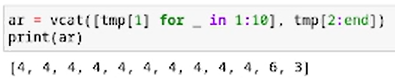

Рисунок 25: Задание 3.5

Задание 3.6.

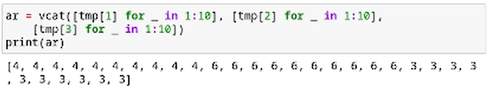

Рисунок 26: Задание 3.6

# Задания для самостоятельной работы

Задание 3.7.

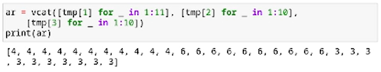

Рисунок 27: Задание 3.7

Задание 3.8.

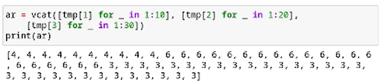

Рисунок 28: Задание 3.8

# Задания для самостоятельной работы

Задание 3.9.

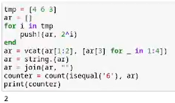

Рисунок 29: Задание 3.9

# Задания для самостоятельной работы

Задание 3.11.

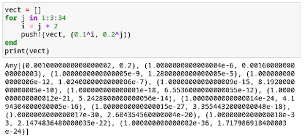

Рисунок 31: Задание 3.11

Задание 3.12.

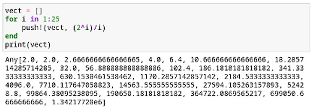

Рисунок 32: Задание 3.12

# Задания для самостоятельной работы

Задание 3.13.

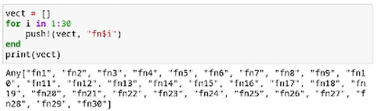

Рисунок 33: Задание 3.13

# Задания для самостоятельной работы

Задание 3.14.

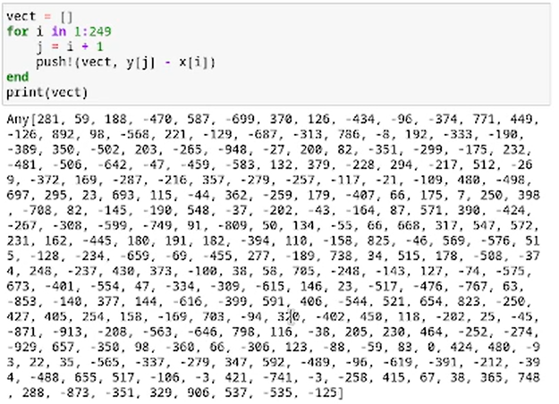

Рисунок 34: Задание 3.14.1